# Risk Factor Analysis

## Outcome Variable

**Outcome Variable:** sstunted

## Predictor Variables

**Intervention Variable:** birthwt

**Adjustment Set:**

- arm
- sex
- W_mage
- meducyrs
- feducyrs
- vagbrth
- single
- brthmon
- W_parity
- delta_W_mage
- delta_meducyrs
- delta_feducyrs
- delta_vagbrth
- delta_single
- delta_brthmon
- delta_W_parity

## Stratifying Variables

The analysis was stratified on these variable(s):

- agecat
- studyid
- country

## Data Summary

| agecat | studyid | country | birthwt | sstunted | n_cell | n |
| --- | --- | --- | --- | --- | --- | --- |
| Birth | CMC-V-BCS-2002 | INDIA | Normal or high birthweight | 0 | 78 | 92 |
| Birth | CMC-V-BCS-2002 | INDIA | Normal or high birthweight | 1 | 3 | 92 |
| Birth | CMC-V-BCS-2002 | INDIA | Low birthweight | 0 | 10 | 92 |
| Birth | CMC-V-BCS-2002 | INDIA | Low birthweight | 1 | 1 | 92 |
| Birth | CMIN | BANGLADESH | Normal or high birthweight | 0 | 14 | 26 |
| Birth | CMIN | BANGLADESH | Normal or high birthweight | 1 | 0 | 26 |
| Birth | CMIN | BANGLADESH | Low birthweight | 0 | 6 | 26 |
| Birth | CMIN | BANGLADESH | Low birthweight | 1 | 6 | 26 |
| Birth | COHORTS | GUATEMALA | Normal or high birthweight | 0 | 713 | 784 |
| Birth | COHORTS | GUATEMALA | Normal or high birthweight | 1 | 4 | 784 |
| Birth | COHORTS | GUATEMALA | Low birthweight | 0 | 61 | 784 |
| Birth | COHORTS | GUATEMALA | Low birthweight | 1 | 6 | 784 |
| Birth | COHORTS | INDIA | Normal or high birthweight | 0 | 5242 | 6638 |
| Birth | COHORTS | INDIA | Normal or high birthweight | 1 | 26 | 6638 |
| Birth | COHORTS | INDIA | Low birthweight | 0 | 1190 | 6638 |
| Birth | COHORTS | INDIA | Low birthweight | 1 | 180 | 6638 |
| Birth | COHORTS | PHILIPPINES | Normal or high birthweight | 0 | 2704 | 3004 |
| Birth | COHORTS | PHILIPPINES | Normal or high birthweight | 1 | 5 | 3004 |
| Birth | COHORTS | PHILIPPINES | Low birthweight | 0 | 255 | 3004 |
| Birth | COHORTS | PHILIPPINES | Low birthweight | 1 | 40 | 3004 |
| Birth | CONTENT | PERU | Normal or high birthweight | 0 | 2 | 2 |
| Birth | CONTENT | PERU | Normal or high birthweight | 1 | 0 | 2 |
| Birth | CONTENT | PERU | Low birthweight | 0 | 0 | 2 |
| Birth | CONTENT | PERU | Low birthweight | 1 | 0 | 2 |
| Birth | EE | PAKISTAN | Normal or high birthweight | 0 | 148 | 240 |
| Birth | EE | PAKISTAN | Normal or high birthweight | 1 | 12 | 240 |
| Birth | EE | PAKISTAN | Low birthweight | 0 | 44 | 240 |
| Birth | EE | PAKISTAN | Low birthweight | 1 | 36 | 240 |
| Birth | GMS-Nepal | NEPAL | Normal or high birthweight | 0 | 475 | 696 |
| Birth | GMS-Nepal | NEPAL | Normal or high birthweight | 1 | 1 | 696 |

[output cut: 282 more lines]

The following strata were considered:

- agecat: 24 months, studyid: CMC-V-BCS-2002, country: INDIA
- agecat: 24 months, studyid: CMIN, country: BANGLADESH
- agecat: 24 months, studyid: COHORTS, country: GUATEMALA
- agecat: 24 months, studyid: COHORTS, country: INDIA
- agecat: 24 months, studyid: COHORTS, country: PHILIPPINES
- agecat: 24 months, studyid: CONTENT, country: PERU
- agecat: 24 months, studyid: EE, country: PAKISTAN
- agecat: 24 months, studyid: GMS-Nepal, country: NEPAL
- agecat: 24 months, studyid: IRC, country: INDIA
- agecat: 24 months, studyid: JiVitA-3, country: BANGLADESH
- agecat: 24 months, studyid: JiVitA-4, country: BANGLADESH
- agecat: 24 months, studyid: Keneba, country: GAMBIA
- agecat: 24 months, studyid: MAL-ED, country: BANGLADESH
- agecat: 24 months, studyid: MAL-ED, country: BRAZIL
- agecat: 24 months, studyid: MAL-ED, country: INDIA
- agecat: 24 months, studyid: MAL-ED, country: NEPAL
- agecat: 24 months, studyid: MAL-ED, country: PERU
- agecat: 24 months, studyid: MAL-ED, country: SOUTH AFRICA
- agecat: 24 months, studyid: MAL-ED, country: TANZANIA, UNITED REPUBLIC OF
- agecat: 24 months, studyid: NIH-Birth, country: BANGLADESH
- agecat: 24 months, studyid: NIH-Crypto, country: BANGLADESH
- agecat: 24 months, studyid: PROBIT, country: BELARUS
- agecat: 24 months, studyid: PROVIDE, country: BANGLADESH
- agecat: 24 months, studyid: TanzaniaChild2, country: TANZANIA, UNITED REPUBLIC OF
- agecat: 24 months, studyid: ZVITAMBO, country: ZIMBABWE
- agecat: 6 months, studyid: CMC-V-BCS-2002, country: INDIA
- agecat: 6 months, studyid: CMIN, country: BANGLADESH
- agecat: 6 months, studyid: COHORTS, country: GUATEMALA
- agecat: 6 months, studyid: COHORTS, country: INDIA
- agecat: 6 months, studyid: COHORTS, country: PHILIPPINES
- agecat: 6 months, studyid: CONTENT, country: PERU
- agecat: 6 months, studyid: EE, country: PAKISTAN
- agecat: 6 months, studyid: GMS-Nepal, country: NEPAL
- agecat: 6 months, studyid: IRC, country: INDIA
- agecat: 6 months, studyid: JiVitA-3, country: BANGLADESH
- agecat: 6 months, studyid: JiVitA-4, country: BANGLADESH
- agecat: 6 months, studyid: Keneba, country: GAMBIA
- agecat: 6 months, studyid: MAL-ED, country: BANGLADESH
- agecat: 6 months, studyid: MAL-ED, country: BRAZIL
- agecat: 6 months, studyid: MAL-ED, country: INDIA
- agecat: 6 months, studyid: MAL-ED, country: NEPAL
- agecat: 6 months, studyid: MAL-ED, country: PERU
- agecat: 6 months, studyid: MAL-ED, country: SOUTH AFRICA
- agecat: 6 months, studyid: MAL-ED, country: TANZANIA, UNITED REPUBLIC OF
- agecat: 6 months, studyid: NIH-Birth, country: BANGLADESH
- agecat: 6 months, studyid: NIH-Crypto, country: BANGLADESH
- agecat: 6 months, studyid: PROBIT, country: BELARUS
- agecat: 6 months, studyid: PROVIDE, country: BANGLADESH
- agecat: 6 months, studyid: ResPak, country: PAKISTAN
- agecat: 6 months, studyid: SAS-CompFeed, country: INDIA
- agecat: 6 months, studyid: TanzaniaChild2, country: TANZANIA, UNITED REPUBLIC OF
- agecat: 6 months, studyid: ZVITAMBO, country: ZIMBABWE
- agecat: Birth, studyid: CMC-V-BCS-2002, country: INDIA
- agecat: Birth, studyid: CMIN, country: BANGLADESH
- agecat: Birth, studyid: COHORTS, country: GUATEMALA
- agecat: Birth, studyid: COHORTS, country: INDIA
- agecat: Birth, studyid: COHORTS, country: PHILIPPINES
- agecat: Birth, studyid: CONTENT, country: PERU
- agecat: Birth, studyid: EE, country: PAKISTAN
- agecat: Birth, studyid: GMS-Nepal, country: NEPAL
- agecat: Birth, studyid: IRC, country: INDIA
- agecat: Birth, studyid: JiVitA-3, country: BANGLADESH
- agecat: Birth, studyid: JiVitA-4, country: BANGLADESH
- agecat: Birth, studyid: Keneba, country: GAMBIA
- agecat: Birth, studyid: MAL-ED, country: BANGLADESH
- agecat: Birth, studyid: MAL-ED, country: BRAZIL
- agecat: Birth, studyid: MAL-ED, country: INDIA
- agecat: Birth, studyid: MAL-ED, country: NEPAL
- agecat: Birth, studyid: MAL-ED, country: PERU
- agecat: Birth, studyid: MAL-ED, country: SOUTH AFRICA
- agecat: Birth, studyid: MAL-ED, country: TANZANIA, UNITED REPUBLIC OF
- agecat: Birth, studyid: NIH-Birth, country: BANGLADESH
- agecat: Birth, studyid: NIH-Crypto, country: BANGLADESH
- agecat: Birth, studyid: PROBIT, country: BELARUS
- agecat: Birth, studyid: PROVIDE, country: BANGLADESH
- agecat: Birth, studyid: ResPak, country: PAKISTAN
- agecat: Birth, studyid: SAS-CompFeed, country: INDIA
- agecat: Birth, studyid: ZVITAMBO, country: ZIMBABWE

### Dropped Strata

Some strata were dropped due to rare outcomes:

- agecat: Birth, studyid: CMC-V-BCS-2002, country: INDIA
- agecat: Birth, studyid: CMIN, country: BANGLADESH
- agecat: Birth, studyid: COHORTS, country: GUATEMALA
- agecat: Birth, studyid: CONTENT, country: PERU
- agecat: Birth, studyid: GMS-Nepal, country: NEPAL
- agecat: Birth, studyid: MAL-ED, country: BANGLADESH
- agecat: Birth, studyid: MAL-ED, country: BRAZIL
- agecat: Birth, studyid: MAL-ED, country: INDIA
- agecat: Birth, studyid: MAL-ED, country: NEPAL
- agecat: Birth, studyid: MAL-ED, country: PERU
- agecat: Birth, studyid: MAL-ED, country: SOUTH AFRICA
- agecat: Birth, studyid: MAL-ED, country: TANZANIA, UNITED REPUBLIC OF
- agecat: Birth, studyid: NIH-Birth, country: BANGLADESH
- agecat: Birth, studyid: NIH-Crypto, country: BANGLADESH
- agecat: Birth, studyid: PROBIT, country: BELARUS
- agecat: Birth, studyid: PROVIDE, country: BANGLADESH
- agecat: Birth, studyid: ResPak, country: PAKISTAN
- agecat: 6 months, studyid: CMIN, country: BANGLADESH
- agecat: 6 months, studyid: CONTENT, country: PERU
- agecat: 6 months, studyid: MAL-ED, country: BANGLADESH
- agecat: 6 months, studyid: MAL-ED, country: BRAZIL
- agecat: 6 months, studyid: MAL-ED, country: INDIA
- agecat: 6 months, studyid: MAL-ED, country: NEPAL
- agecat: 6 months, studyid: MAL-ED, country: PERU
- agecat: 6 months, studyid: MAL-ED, country: SOUTH AFRICA
- agecat: 6 months, studyid: MAL-ED, country: TANZANIA, UNITED REPUBLIC OF
- agecat: 6 months, studyid: PROBIT, country: BELARUS
- agecat: 6 months, studyid: PROVIDE, country: BANGLADESH
- agecat: 6 months, studyid: ResPak, country: PAKISTAN
- agecat: 6 months, studyid: TanzaniaChild2, country: TANZANIA, UNITED REPUBLIC OF
- agecat: 24 months, studyid: CMIN, country: BANGLADESH
- agecat: 24 months, studyid: CONTENT, country: PERU
- agecat: 24 months, studyid: MAL-ED, country: BRAZIL
- agecat: 24 months, studyid: MAL-ED, country: NEPAL
- agecat: 24 months, studyid: MAL-ED, country: PERU
- agecat: 24 months, studyid: MAL-ED, country: SOUTH AFRICA
- agecat: 24 months, studyid: MAL-ED, country: TANZANIA, UNITED REPUBLIC OF
- agecat: 24 months, studyid: PROBIT, country: BELARUS
- agecat: 24 months, studyid: TanzaniaChild2, country: TANZANIA, UNITED REPUBLIC OF

## Methods Detail

We’re interested in the causal parameters $E[Y_a]$ for all values of $a \in \mathcal{A}$. These parameters represent the mean outcome if, possibly contrary to fact, we intervened to set all units to have $A=a$. Under the randomization and positivity assumptions, these are identified by the statistical parameters $\psi_a=E_W[E_{Y|A,W}(Y|A=a,W)]$. In addition, we’re interested in the mean of $Y$, $E[Y]$ under no intervention (the observed mean). We will estimate these parameters by using SuperLearner to fit the relevant likelihood factors – $E_{Y|A,W}(Y|A=a,W)$ and $p(A=a|W)$, and then updating our likelihood fit using a joint TMLE.

For unadjusted analyses ($W=\{\}$), initial likelihoods were estimated using Lrnr_glm to estimate the simple $E(Y|A)$ and Lrnr_mean to estimate $p(A)$. For adjusted analyses, a small library containing Lrnr_glmnet, Lrnr_xgboost, and Lrnr_mean was used.

Having estimated these parameters, we will then use the delta method to estimate relative risks and attributable risks relative to a prespecified baseline level of $A$.

# Results Detail

## Results Plots

[figure not shown]

[figure not shown]

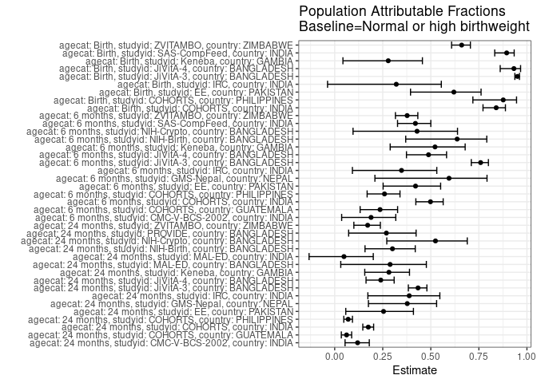

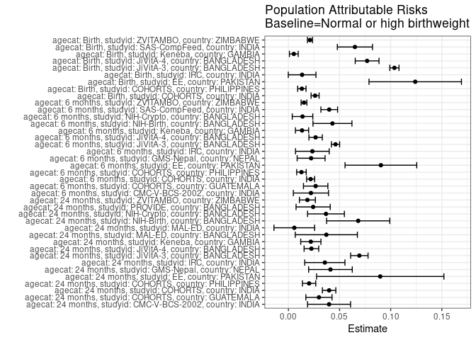

## Results Table

### Parameter: TSM

| agecat | studyid | country | intervention_level | baseline_level | estimate | ci_lower | ci_upper |
| --- | --- | --- | --- | --- | --- | --- | --- |
| Birth | COHORTS | INDIA | Normal or high birthweight | NA | 0.0049607 | 0.0030606 | 0.0068608 |
| Birth | COHORTS | INDIA | Low birthweight | NA | 0.1282991 | 0.1106047 | 0.1459936 |
| Birth | COHORTS | PHILIPPINES | Normal or high birthweight | NA | 0.0018457 | 0.0002291 | 0.0034623 |
| Birth | COHORTS | PHILIPPINES | Low birthweight | NA | 0.1355932 | 0.0965193 | 0.1746672 |
| Birth | EE | PAKISTAN | Normal or high birthweight | NA | 0.0760142 | 0.0342192 | 0.1178092 |
| Birth | EE | PAKISTAN | Low birthweight | NA | 0.4509550 | 0.3398843 | 0.5620256 |
| Birth | IRC | INDIA | Normal or high birthweight | NA | 0.0283912 | 0.0100839 | 0.0466984 |
| Birth | IRC | INDIA | Low birthweight | NA | 0.1060606 | 0.0316774 | 0.1804438 |
| Birth | JiVitA-3 | BANGLADESH | Normal or high birthweight | NA | 0.0053923 | 0.0040814 | 0.0067031 |
| Birth | JiVitA-3 | BANGLADESH | Low birthweight | NA | 0.2387851 | 0.2294685 | 0.2481018 |
| Birth | JiVitA-4 | BANGLADESH | Normal or high birthweight | NA | 0.0055907 | 0.0014979 | 0.0096836 |
| Birth | JiVitA-4 | BANGLADESH | Low birthweight | NA | 0.2173630 | 0.1880083 | 0.2467178 |
| Birth | Keneba | GAMBIA | Normal or high birthweight | NA | 0.0136819 | 0.0073846 | 0.0199792 |
| Birth | Keneba | GAMBIA | Low birthweight | NA | 0.0486955 | 0.0205549 | 0.0768360 |
| Birth | SAS-CompFeed | INDIA | Normal or high birthweight | NA | 0.0076586 | 0.0028611 | 0.0124562 |
| Birth | SAS-CompFeed | INDIA | Low birthweight | NA | 0.2485207 | 0.1798026 | 0.3172388 |
| Birth | ZVITAMBO | ZIMBABWE | Normal or high birthweight | NA | 0.0108258 | 0.0089687 | 0.0126829 |
| Birth | ZVITAMBO | ZIMBABWE | Low birthweight | NA | 0.1618723 | 0.1452647 | 0.1784800 |
| 6 months | CMC-V-BCS-2002 | INDIA | Normal or high birthweight | NA | 0.0943370 | 0.0622838 | 0.1263901 |
| 6 months | CMC-V-BCS-2002 | INDIA | Low birthweight | NA | 0.2891445 | 0.1528279 | 0.4254611 |
| 6 months | COHORTS | GUATEMALA | Normal or high birthweight | NA | 0.0862110 | 0.0654401 | 0.1069818 |
| 6 months | COHORTS | GUATEMALA | Low birthweight | NA | 0.3807510 | 0.2639544 | 0.4975476 |
| 6 months | COHORTS | INDIA | Normal or high birthweight | NA | 0.0218772 | 0.0178348 | 0.0259197 |
| 6 months | COHORTS | INDIA | Low birthweight | NA | 0.1275040 | 0.1088178 | 0.1461901 |
| 6 months | COHORTS | PHILIPPINES | Normal or high birthweight | NA | 0.0364049 | 0.0289473 | 0.0438626 |
| 6 months | COHORTS | PHILIPPINES | Low birthweight | NA | 0.1705043 | 0.1244354 | 0.2165731 |
| 6 months | EE | PAKISTAN | Normal or high birthweight | NA | 0.1246246 | 0.0830700 | 0.1661791 |
| 6 months | EE | PAKISTAN | Low birthweight | NA | 0.3917661 | 0.3073638 | 0.4761683 |
| 6 months | GMS-Nepal | NEPAL | Normal or high birthweight | NA | 0.0151134 | 0.0031014 | 0.0271253 |
| 6 months | GMS-Nepal | NEPAL | Low birthweight | NA | 0.0903614 | 0.0467092 | 0.1340136 |
| 6 months | IRC | INDIA | Normal or high birthweight | NA | 0.0439299 | 0.0217819 | 0.0660780 |
| 6 months | IRC | INDIA | Low birthweight | NA | 0.1834244 | 0.0876213 | 0.2792276 |
| 6 months | JiVitA-3 | BANGLADESH | Normal or high birthweight | NA | 0.0146067 | 0.0116406 | 0.0175729 |
| 6 months | JiVitA-3 | BANGLADESH | Low birthweight | NA | 0.1248017 | 0.1156097 | 0.1339936 |
| 6 months | JiVitA-4 | BANGLADESH | Normal or high birthweight | NA | 0.0278662 | 0.0203207 | 0.0354118 |
| 6 months | JiVitA-4 | BANGLADESH | Low birthweight | NA | 0.1299399 | 0.1052950 | 0.1545849 |
| 6 months | Keneba | GAMBIA | Normal or high birthweight | NA | 0.0121852 | 0.0058108 | 0.0185596 |
| 6 months | Keneba | GAMBIA | Low birthweight | NA | 0.1002475 | 0.0561547 | 0.1443403 |
| 6 months | NIH-Birth | BANGLADESH | Normal or high birthweight | NA | 0.0245232 | 0.0086840 | 0.0403623 |
| 6 months | NIH-Birth | BANGLADESH | Low birthweight | NA | 0.1721854 | 0.1119095 | 0.2324614 |
| 6 months | NIH-Crypto | BANGLADESH | Normal or high birthweight | NA | 0.0183849 | 0.0070961 | 0.0296738 |
| 6 months | NIH-Crypto | BANGLADESH | Low birthweight | NA | 0.0794632 | 0.0391968 | 0.1197296 |
| 6 months | SAS-CompFeed | INDIA | Normal or high birthweight | NA | 0.0551213 | 0.0388056 | 0.0714371 |
| 6 months | SAS-CompFeed | INDIA | Low birthweight | NA | 0.2162155 | 0.1784565 | 0.2539745 |
| 6 months | ZVITAMBO | ZIMBABWE | Normal or high birthweight | NA | 0.0251807 | 0.0216462 | 0.0287153 |
| 6 months | ZVITAMBO | ZIMBABWE | Low birthweight | NA | 0.1518423 | 0.1306647 | 0.1730198 |
| 24 months | CMC-V-BCS-2002 | INDIA | Normal or high birthweight | NA | 0.2936024 | 0.2435718 | 0.3436330 |
| 24 months | CMC-V-BCS-2002 | INDIA | Low birthweight | NA | 0.6251198 | 0.4791358 | 0.7711038 |
| 24 months | COHORTS | GUATEMALA | Normal or high birthweight | NA | 0.4532358 | 0.4129615 | 0.4935101 |
| 24 months | COHORTS | GUATEMALA | Low birthweight | NA | 0.7694826 | 0.6586869 | 0.8802783 |
| 24 months | COHORTS | INDIA | Normal or high birthweight | NA | 0.1876832 | 0.1756133 | 0.1997532 |
| 24 months | COHORTS | INDIA | Low birthweight | NA | 0.3935729 | 0.3625225 | 0.4246233 |
| 24 months | COHORTS | PHILIPPINES | Normal or high birthweight | NA | 0.2678229 | 0.2493448 | 0.2863009 |
| 24 months | COHORTS | PHILIPPINES | Low birthweight | NA | 0.4961333 | 0.4305114 | 0.5617552 |
| 24 months | EE | PAKISTAN | Normal or high birthweight | NA | 0.2635190 | 0.1768713 | 0.3501666 |
| 24 months | EE | PAKISTAN | Low birthweight | NA | 0.4987259 | 0.3756170 | 0.6218348 |
| 24 months | GMS-Nepal | NEPAL | Normal or high birthweight | NA | 0.0677360 | 0.0415181 | 0.0939538 |
| 24 months | GMS-Nepal | NEPAL | Low birthweight | NA | 0.2184466 | 0.1460128 | 0.2908805 |
| 24 months | IRC | INDIA | Normal or high birthweight | NA | 0.0562109 | 0.0313788 | 0.0810430 |
| 24 months | IRC | INDIA | Low birthweight | NA | 0.2660136 | 0.1568474 | 0.3751798 |
| 24 months | JiVitA-3 | BANGLADESH | Normal or high birthweight | NA | 0.0906334 | 0.0808461 | 0.1004207 |
| 24 months | JiVitA-3 | BANGLADESH | Low birthweight | NA | 0.2533569 | 0.2359645 | 0.2707492 |
| 24 months | JiVitA-4 | BANGLADESH | Normal or high birthweight | NA | 0.0712933 | 0.0605693 | 0.0820173 |
| 24 months | JiVitA-4 | BANGLADESH | Low birthweight | NA | 0.1531620 | 0.1292573 | 0.1770668 |
| 24 months | Keneba | GAMBIA | Normal or high birthweight | NA | 0.0557456 | 0.0407271 | 0.0707640 |
| 24 months | Keneba | GAMBIA | Low birthweight | NA | 0.2144918 | 0.1491086 | 0.2798749 |
| 24 months | MAL-ED | BANGLADESH | Normal or high birthweight | NA | 0.0915206 | 0.0474806 | 0.1355606 |
| 24 months | MAL-ED | BANGLADESH | Low birthweight | NA | 0.2428727 | 0.1080309 | 0.3777146 |
| 24 months | MAL-ED | INDIA | Normal or high birthweight | NA | 0.1135135 | 0.0676972 | 0.1593299 |
| 24 months | MAL-ED | INDIA | Low birthweight | NA | 0.1515152 | 0.0289013 | 0.2741290 |
| 24 months | NIH-Birth | BANGLADESH | Normal or high birthweight | NA | 0.1588219 | 0.1162334 | 0.2014104 |
| 24 months | NIH-Birth | BANGLADESH | Low birthweight | NA | 0.3821298 | 0.2966780 | 0.4675816 |
| 24 months | NIH-Crypto | BANGLADESH | Normal or high birthweight | NA | 0.0333212 | 0.0153202 | 0.0513222 |
| 24 months | NIH-Crypto | BANGLADESH | Low birthweight | NA | 0.1714984 | 0.1033071 | 0.2396897 |
| 24 months | PROVIDE | BANGLADESH | Normal or high birthweight | NA | 0.0657858 | 0.0423804 | 0.0891911 |
| 24 months | PROVIDE | BANGLADESH | Low birthweight | NA | 0.1653359 | 0.0995474 | 0.2311244 |
| 24 months | ZVITAMBO | ZIMBABWE | Normal or high birthweight | NA | 0.0896923 | 0.0749456 | 0.1044391 |
| 24 months | ZVITAMBO | ZIMBABWE | Low birthweight | NA | 0.2442546 | 0.1829399 | 0.3055692 |

### Parameter: E(Y)

| agecat | studyid | country | intervention_level | baseline_level | estimate | ci_lower | ci_upper |
| --- | --- | --- | --- | --- | --- | --- | --- |
| Birth | COHORTS | INDIA | NA | NA | 0.0310334 | 0.0268616 | 0.0352053 |
| Birth | COHORTS | PHILIPPINES | NA | NA | 0.0149800 | 0.0106354 | 0.0193246 |
| Birth | EE | PAKISTAN | NA | NA | 0.2000000 | 0.1492882 | 0.2507118 |
| Birth | IRC | INDIA | NA | NA | 0.0417755 | 0.0217118 | 0.0618391 |
| Birth | JiVitA-3 | BANGLADESH | NA | NA | 0.1090229 | 0.1044694 | 0.1135764 |
| Birth | JiVitA-4 | BANGLADESH | NA | NA | 0.0825363 | 0.0708486 | 0.0942240 |
| Birth | Keneba | GAMBIA | NA | NA | 0.0189666 | 0.0121272 | 0.0258061 |
| Birth | SAS-CompFeed | INDIA | NA | NA | 0.0726837 | 0.0523147 | 0.0930527 |
| Birth | ZVITAMBO | ZIMBABWE | NA | NA | 0.0318872 | 0.0289588 | 0.0348156 |
| 6 months | CMC-V-BCS-2002 | INDIA | NA | NA | 0.1163435 | 0.0832220 | 0.1494650 |
| 6 months | COHORTS | GUATEMALA | NA | NA | 0.1128405 | 0.0904926 | 0.1351883 |
| 6 months | COHORTS | INDIA | NA | NA | 0.0436033 | 0.0385446 | 0.0486620 |
| 6 months | COHORTS | PHILIPPINES | NA | NA | 0.0491373 | 0.0409307 | 0.0573439 |
| 6 months | EE | PAKISTAN | NA | NA | 0.2150538 | 0.1732462 | 0.2568613 |
| 6 months | GMS-Nepal | NEPAL | NA | NA | 0.0373002 | 0.0216334 | 0.0529670 |
| 6 months | IRC | INDIA | NA | NA | 0.0673317 | 0.0427738 | 0.0918896 |
| 6 months | JiVitA-3 | BANGLADESH | NA | NA | 0.0606511 | 0.0563622 | 0.0649400 |
| 6 months | JiVitA-4 | BANGLADESH | NA | NA | 0.0544420 | 0.0459722 | 0.0629117 |
| 6 months | Keneba | GAMBIA | NA | NA | 0.0254873 | 0.0170269 | 0.0339476 |
| 6 months | NIH-Birth | BANGLADESH | NA | NA | 0.0675676 | 0.0459314 | 0.0892038 |
| 6 months | NIH-Crypto | BANGLADESH | NA | NA | 0.0321678 | 0.0192256 | 0.0451101 |
| 6 months | SAS-CompFeed | INDIA | NA | NA | 0.0950226 | 0.0765320 | 0.1135132 |
| 6 months | ZVITAMBO | ZIMBABWE | NA | NA | 0.0404122 | 0.0362587 | 0.0445657 |
| 24 months | CMC-V-BCS-2002 | INDIA | NA | NA | 0.3333333 | 0.2847723 | 0.3818943 |
| 24 months | COHORTS | GUATEMALA | NA | NA | 0.4830769 | 0.4446313 | 0.5215225 |
| 24 months | COHORTS | INDIA | NA | NA | 0.2274599 | 0.2156709 | 0.2392489 |
| 24 months | COHORTS | PHILIPPINES | NA | NA | 0.2880299 | 0.2699315 | 0.3061283 |
| 24 months | EE | PAKISTAN | NA | NA | 0.3532934 | 0.2805798 | 0.4260070 |
| 24 months | GMS-Nepal | NEPAL | NA | NA | 0.1088296 | 0.0811421 | 0.1365171 |
| 24 months | IRC | INDIA | NA | NA | 0.0918114 | 0.0635840 | 0.1200389 |
| 24 months | JiVitA-3 | BANGLADESH | NA | NA | 0.1599836 | 0.1502803 | 0.1696868 |
| 24 months | JiVitA-4 | BANGLADESH | NA | NA | 0.0937656 | 0.0834379 | 0.1040932 |
| 24 months | Keneba | GAMBIA | NA | NA | 0.0776515 | 0.0615026 | 0.0938005 |
| 24 months | MAL-ED | BANGLADESH | NA | NA | 0.1285714 | 0.0831916 | 0.1739513 |
| 24 months | MAL-ED | INDIA | NA | NA | 0.1192661 | 0.0761440 | 0.1623881 |
| 24 months | NIH-Birth | BANGLADESH | NA | NA | 0.2270531 | 0.1866503 | 0.2674560 |
| 24 months | NIH-Crypto | BANGLADESH | NA | NA | 0.0700389 | 0.0479542 | 0.0921236 |
| 24 months | PROVIDE | BANGLADESH | NA | NA | 0.0899654 | 0.0666186 | 0.1133122 |
| 24 months | ZVITAMBO | ZIMBABWE | NA | NA | 0.1082569 | 0.0931919 | 0.1233219 |

### Parameter: RR

| agecat | studyid | country | intervention_level | baseline_level | estimate | ci_lower | ci_upper |
| --- | --- | --- | --- | --- | --- | --- | --- |
| Birth | COHORTS | INDIA | Normal or high birthweight | Normal or high birthweight | 1.000000 | 1.0000000 | 1.000000 |
| Birth | COHORTS | INDIA | Low birthweight | Normal or high birthweight | 25.863153 | 17.2143886 | 38.857185 |
| Birth | COHORTS | PHILIPPINES | Normal or high birthweight | Normal or high birthweight | 1.000000 | 1.0000000 | 1.000000 |
| Birth | COHORTS | PHILIPPINES | Low birthweight | Normal or high birthweight | 73.464407 | 29.2170860 | 184.721332 |
| Birth | EE | PAKISTAN | Normal or high birthweight | Normal or high birthweight | 1.000000 | 1.0000000 | 1.000000 |
| Birth | EE | PAKISTAN | Low birthweight | Normal or high birthweight | 5.932509 | 3.2466588 | 10.840270 |
| Birth | IRC | INDIA | Normal or high birthweight | Normal or high birthweight | 1.000000 | 1.0000000 | 1.000000 |
| Birth | IRC | INDIA | Low birthweight | Normal or high birthweight | 3.735690 | 1.4408347 | 9.685623 |
| Birth | JiVitA-3 | BANGLADESH | Normal or high birthweight | Normal or high birthweight | 1.000000 | 1.0000000 | 1.000000 |
| Birth | JiVitA-3 | BANGLADESH | Low birthweight | Normal or high birthweight | 44.282967 | 34.7104516 | 56.495410 |
| Birth | JiVitA-4 | BANGLADESH | Normal or high birthweight | Normal or high birthweight | 1.000000 | 1.0000000 | 1.000000 |
| Birth | JiVitA-4 | BANGLADESH | Low birthweight | Normal or high birthweight | 38.879175 | 18.3719457 | 82.277093 |
| Birth | Keneba | GAMBIA | Normal or high birthweight | Normal or high birthweight | 1.000000 | 1.0000000 | 1.000000 |
| Birth | Keneba | GAMBIA | Low birthweight | Normal or high birthweight | 3.559125 | 1.6991666 | 7.455049 |
| Birth | SAS-CompFeed | INDIA | Normal or high birthweight | Normal or high birthweight | 1.000000 | 1.0000000 | 1.000000 |
| Birth | SAS-CompFeed | INDIA | Low birthweight | Normal or high birthweight | 32.449704 | 19.4675936 | 54.089032 |
| Birth | ZVITAMBO | ZIMBABWE | Normal or high birthweight | Normal or high birthweight | 1.000000 | 1.0000000 | 1.000000 |
| Birth | ZVITAMBO | ZIMBABWE | Low birthweight | Normal or high birthweight | 14.952407 | 12.2436973 | 18.260372 |
| 6 months | CMC-V-BCS-2002 | INDIA | Normal or high birthweight | Normal or high birthweight | 1.000000 | 1.0000000 | 1.000000 |
| 6 months | CMC-V-BCS-2002 | INDIA | Low birthweight | Normal or high birthweight | 3.065018 | 1.7210056 | 5.458631 |
| 6 months | COHORTS | GUATEMALA | Normal or high birthweight | Normal or high birthweight | 1.000000 | 1.0000000 | 1.000000 |
| 6 months | COHORTS | GUATEMALA | Low birthweight | Normal or high birthweight | 4.416503 | 2.9888444 | 6.526099 |
| 6 months | COHORTS | INDIA | Normal or high birthweight | Normal or high birthweight | 1.000000 | 1.0000000 | 1.000000 |
| 6 months | COHORTS | INDIA | Low birthweight | Normal or high birthweight | 5.828157 | 4.6062659 | 7.374175 |
| 6 months | COHORTS | PHILIPPINES | Normal or high birthweight | Normal or high birthweight | 1.000000 | 1.0000000 | 1.000000 |
| 6 months | COHORTS | PHILIPPINES | Low birthweight | Normal or high birthweight | 4.683548 | 3.3383610 | 6.570775 |
| 6 months | EE | PAKISTAN | Normal or high birthweight | Normal or high birthweight | 1.000000 | 1.0000000 | 1.000000 |
| 6 months | EE | PAKISTAN | Low birthweight | Normal or high birthweight | 3.143569 | 2.1107403 | 4.681783 |
| 6 months | GMS-Nepal | NEPAL | Normal or high birthweight | Normal or high birthweight | 1.000000 | 1.0000000 | 1.000000 |
| 6 months | GMS-Nepal | NEPAL | Low birthweight | Normal or high birthweight | 5.978916 | 2.3588012 | 15.154915 |
| 6 months | IRC | INDIA | Normal or high birthweight | Normal or high birthweight | 1.000000 | 1.0000000 | 1.000000 |
| 6 months | IRC | INDIA | Low birthweight | Normal or high birthweight | 4.175386 | 2.0249624 | 8.609467 |
| 6 months | JiVitA-3 | BANGLADESH | Normal or high birthweight | Normal or high birthweight | 1.000000 | 1.0000000 | 1.000000 |
| 6 months | JiVitA-3 | BANGLADESH | Low birthweight | Normal or high birthweight | 8.544125 | 6.9032031 | 10.575102 |
| 6 months | JiVitA-4 | BANGLADESH | Normal or high birthweight | Normal or high birthweight | 1.000000 | 1.0000000 | 1.000000 |
| 6 months | JiVitA-4 | BANGLADESH | Low birthweight | Normal or high birthweight | 4.662990 | 3.3570214 | 6.477013 |
| 6 months | Keneba | GAMBIA | Normal or high birthweight | Normal or high birthweight | 1.000000 | 1.0000000 | 1.000000 |
| 6 months | Keneba | GAMBIA | Low birthweight | Normal or high birthweight | 8.227007 | 4.1648966 | 16.250978 |
| 6 months | NIH-Birth | BANGLADESH | Normal or high birthweight | Normal or high birthweight | 1.000000 | 1.0000000 | 1.000000 |
| 6 months | NIH-Birth | BANGLADESH | Low birthweight | Normal or high birthweight | 7.021339 | 3.3679464 | 14.637764 |
| 6 months | NIH-Crypto | BANGLADESH | Normal or high birthweight | Normal or high birthweight | 1.000000 | 1.0000000 | 1.000000 |
| 6 months | NIH-Crypto | BANGLADESH | Low birthweight | Normal or high birthweight | 4.322192 | 1.9489421 | 9.585375 |
| 6 months | SAS-CompFeed | INDIA | Normal or high birthweight | Normal or high birthweight | 1.000000 | 1.0000000 | 1.000000 |
| 6 months | SAS-CompFeed | INDIA | Low birthweight | Normal or high birthweight | 3.922537 | 2.8919735 | 5.320346 |
| 6 months | ZVITAMBO | ZIMBABWE | Normal or high birthweight | Normal or high birthweight | 1.000000 | 1.0000000 | 1.000000 |
| 6 months | ZVITAMBO | ZIMBABWE | Low birthweight | Normal or high birthweight | 6.030097 | 4.9487297 | 7.347759 |
| 24 months | CMC-V-BCS-2002 | INDIA | Normal or high birthweight | Normal or high birthweight | 1.000000 | 1.0000000 | 1.000000 |
| 24 months | CMC-V-BCS-2002 | INDIA | Low birthweight | Normal or high birthweight | 2.129138 | 1.5957605 | 2.840794 |
| 24 months | COHORTS | GUATEMALA | Normal or high birthweight | Normal or high birthweight | 1.000000 | 1.0000000 | 1.000000 |
| 24 months | COHORTS | GUATEMALA | Low birthweight | Normal or high birthweight | 1.697753 | 1.4336008 | 2.010578 |
| 24 months | COHORTS | INDIA | Normal or high birthweight | Normal or high birthweight | 1.000000 | 1.0000000 | 1.000000 |
| 24 months | COHORTS | INDIA | Low birthweight | Normal or high birthweight | 2.097006 | 1.8976908 | 2.317256 |
| 24 months | COHORTS | PHILIPPINES | Normal or high birthweight | Normal or high birthweight | 1.000000 | 1.0000000 | 1.000000 |
| 24 months | COHORTS | PHILIPPINES | Low birthweight | Normal or high birthweight | 1.852468 | 1.5978195 | 2.147701 |
| 24 months | EE | PAKISTAN | Normal or high birthweight | Normal or high birthweight | 1.000000 | 1.0000000 | 1.000000 |
| 24 months | EE | PAKISTAN | Low birthweight | Normal or high birthweight | 1.892562 | 1.2539191 | 2.856476 |
| 24 months | GMS-Nepal | NEPAL | Normal or high birthweight | Normal or high birthweight | 1.000000 | 1.0000000 | 1.000000 |
| 24 months | GMS-Nepal | NEPAL | Low birthweight | Normal or high birthweight | 3.224973 | 1.9373883 | 5.368285 |
| 24 months | IRC | INDIA | Normal or high birthweight | Normal or high birthweight | 1.000000 | 1.0000000 | 1.000000 |
| 24 months | IRC | INDIA | Low birthweight | Normal or high birthweight | 4.732419 | 2.5991059 | 8.616728 |
| 24 months | JiVitA-3 | BANGLADESH | Normal or high birthweight | Normal or high birthweight | 1.000000 | 1.0000000 | 1.000000 |
| 24 months | JiVitA-3 | BANGLADESH | Low birthweight | Normal or high birthweight | 2.795404 | 2.4663558 | 3.168351 |
| 24 months | JiVitA-4 | BANGLADESH | Normal or high birthweight | Normal or high birthweight | 1.000000 | 1.0000000 | 1.000000 |
| 24 months | JiVitA-4 | BANGLADESH | Low birthweight | Normal or high birthweight | 2.148337 | 1.7321060 | 2.664591 |
| 24 months | Keneba | GAMBIA | Normal or high birthweight | Normal or high birthweight | 1.000000 | 1.0000000 | 1.000000 |
| 24 months | Keneba | GAMBIA | Low birthweight | Normal or high birthweight | 3.847693 | 2.5631507 | 5.775993 |
| 24 months | MAL-ED | BANGLADESH | Normal or high birthweight | Normal or high birthweight | 1.000000 | 1.0000000 | 1.000000 |
| 24 months | MAL-ED | BANGLADESH | Low birthweight | Normal or high birthweight | 2.653749 | 1.2823902 | 5.491608 |
| 24 months | MAL-ED | INDIA | Normal or high birthweight | Normal or high birthweight | 1.000000 | 1.0000000 | 1.000000 |
| 24 months | MAL-ED | INDIA | Low birthweight | Normal or high birthweight | 1.334776 | 0.5403395 | 3.297238 |
| 24 months | NIH-Birth | BANGLADESH | Normal or high birthweight | Normal or high birthweight | 1.000000 | 1.0000000 | 1.000000 |
| 24 months | NIH-Birth | BANGLADESH | Low birthweight | Normal or high birthweight | 2.406027 | 1.6988724 | 3.407535 |
| 24 months | NIH-Crypto | BANGLADESH | Normal or high birthweight | Normal or high birthweight | 1.000000 | 1.0000000 | 1.000000 |
| 24 months | NIH-Crypto | BANGLADESH | Low birthweight | Normal or high birthweight | 5.146822 | 2.6317487 | 10.065467 |
| 24 months | PROVIDE | BANGLADESH | Normal or high birthweight | Normal or high birthweight | 1.000000 | 1.0000000 | 1.000000 |
| 24 months | PROVIDE | BANGLADESH | Low birthweight | Normal or high birthweight | 2.513247 | 1.4750903 | 4.282049 |
| 24 months | ZVITAMBO | ZIMBABWE | Normal or high birthweight | Normal or high birthweight | 1.000000 | 1.0000000 | 1.000000 |
| 24 months | ZVITAMBO | ZIMBABWE | Low birthweight | Normal or high birthweight | 2.723249 | 2.0172193 | 3.676389 |

### Parameter: PAR

| agecat | studyid | country | intervention_level | baseline_level | estimate | ci_lower | ci_upper |
| --- | --- | --- | --- | --- | --- | --- | --- |
| Birth | COHORTS | INDIA | Normal or high birthweight | NA | 0.0260728 | 0.0221604 | 0.0299851 |
| Birth | COHORTS | PHILIPPINES | Normal or high birthweight | NA | 0.0131343 | 0.0090385 | 0.0172301 |
| Birth | EE | PAKISTAN | Normal or high birthweight | NA | 0.1239858 | 0.0787847 | 0.1691869 |
| Birth | IRC | INDIA | Normal or high birthweight | NA | 0.0133843 | -0.0001400 | 0.0269086 |
| Birth | JiVitA-3 | BANGLADESH | Normal or high birthweight | NA | 0.1036306 | 0.0991355 | 0.1081258 |
| Birth | JiVitA-4 | BANGLADESH | Normal or high birthweight | NA | 0.0769456 | 0.0653131 | 0.0885780 |
| Birth | Keneba | GAMBIA | Normal or high birthweight | NA | 0.0052848 | 0.0009872 | 0.0095823 |
| Birth | SAS-CompFeed | INDIA | Normal or high birthweight | NA | 0.0650251 | 0.0478410 | 0.0822091 |
| Birth | ZVITAMBO | ZIMBABWE | Normal or high birthweight | NA | 0.0210614 | 0.0185975 | 0.0235252 |
| 6 months | CMC-V-BCS-2002 | INDIA | Normal or high birthweight | NA | 0.0220065 | 0.0048144 | 0.0391987 |
| 6 months | COHORTS | GUATEMALA | Normal or high birthweight | NA | 0.0266295 | 0.0147089 | 0.0385501 |
| 6 months | COHORTS | INDIA | Normal or high birthweight | NA | 0.0217260 | 0.0177818 | 0.0256703 |
| 6 months | COHORTS | PHILIPPINES | Normal or high birthweight | NA | 0.0127323 | 0.0080738 | 0.0173909 |
| 6 months | EE | PAKISTAN | Normal or high birthweight | NA | 0.0904292 | 0.0553733 | 0.1254851 |
| 6 months | GMS-Nepal | NEPAL | Normal or high birthweight | NA | 0.0221868 | 0.0085395 | 0.0358341 |
| 6 months | IRC | INDIA | Normal or high birthweight | NA | 0.0234017 | 0.0069375 | 0.0398660 |
| 6 months | JiVitA-3 | BANGLADESH | Normal or high birthweight | NA | 0.0460444 | 0.0420187 | 0.0500700 |
| 6 months | JiVitA-4 | BANGLADESH | Normal or high birthweight | NA | 0.0265757 | 0.0200292 | 0.0331223 |
| 6 months | Keneba | GAMBIA | Normal or high birthweight | NA | 0.0133021 | 0.0068189 | 0.0197853 |
| 6 months | NIH-Birth | BANGLADESH | Normal or high birthweight | NA | 0.0430444 | 0.0239784 | 0.0621104 |
| 6 months | NIH-Crypto | BANGLADESH | Normal or high birthweight | NA | 0.0137829 | 0.0037367 | 0.0238291 |
| 6 months | SAS-CompFeed | INDIA | Normal or high birthweight | NA | 0.0399013 | 0.0317411 | 0.0480615 |
| 6 months | ZVITAMBO | ZIMBABWE | Normal or high birthweight | NA | 0.0152315 | 0.0124361 | 0.0180269 |
| 24 months | CMC-V-BCS-2002 | INDIA | Normal or high birthweight | NA | 0.0397310 | 0.0186882 | 0.0607738 |
| 24 months | COHORTS | GUATEMALA | Normal or high birthweight | NA | 0.0298411 | 0.0170337 | 0.0426486 |
| 24 months | COHORTS | INDIA | Normal or high birthweight | NA | 0.0397766 | 0.0332154 | 0.0463379 |
| 24 months | COHORTS | PHILIPPINES | Normal or high birthweight | NA | 0.0202071 | 0.0136871 | 0.0267270 |
| 24 months | EE | PAKISTAN | Normal or high birthweight | NA | 0.0897745 | 0.0275209 | 0.1520280 |
| 24 months | GMS-Nepal | NEPAL | Normal or high birthweight | NA | 0.0410936 | 0.0197545 | 0.0624327 |
| 24 months | IRC | INDIA | Normal or high birthweight | NA | 0.0356005 | 0.0159392 | 0.0552618 |
| 24 months | JiVitA-3 | BANGLADESH | Normal or high birthweight | NA | 0.0693502 | 0.0608460 | 0.0778544 |
| 24 months | JiVitA-4 | BANGLADESH | Normal or high birthweight | NA | 0.0224723 | 0.0153313 | 0.0296133 |
| 24 months | Keneba | GAMBIA | Normal or high birthweight | NA | 0.0219060 | 0.0120214 | 0.0317905 |
| 24 months | MAL-ED | BANGLADESH | Normal or high birthweight | NA | 0.0370508 | 0.0066594 | 0.0674422 |
| 24 months | MAL-ED | INDIA | Normal or high birthweight | NA | 0.0057525 | -0.0141444 | 0.0256495 |
| 24 months | NIH-Birth | BANGLADESH | Normal or high birthweight | NA | 0.0682312 | 0.0373252 | 0.0991373 |
| 24 months | NIH-Crypto | BANGLADESH | Normal or high birthweight | NA | 0.0367177 | 0.0187230 | 0.0547124 |
| 24 months | PROVIDE | BANGLADESH | Normal or high birthweight | NA | 0.0241796 | 0.0074638 | 0.0408955 |
| 24 months | ZVITAMBO | ZIMBABWE | Normal or high birthweight | NA | 0.0185645 | 0.0107561 | 0.0263730 |

### Parameter: PAF

| agecat | studyid | country | intervention_level | baseline_level | estimate | ci_lower | ci_upper |
| --- | --- | --- | --- | --- | --- | --- | --- |
| Birth | COHORTS | INDIA | Normal or high birthweight | NA | 0.8401501 | 0.7714883 | 0.8881809 |
| Birth | COHORTS | PHILIPPINES | Normal or high birthweight | NA | 0.8767893 | 0.7188230 | 0.9460095 |
| Birth | EE | PAKISTAN | Normal or high birthweight | NA | 0.6199289 | 0.3944569 | 0.7614472 |
| Birth | IRC | INDIA | Normal or high birthweight | NA | 0.3203864 | -0.0371590 | 0.5546733 |
| Birth | JiVitA-3 | BANGLADESH | Normal or high birthweight | NA | 0.9505401 | 0.9372001 | 0.9610465 |
| Birth | JiVitA-4 | BANGLADESH | Normal or high birthweight | NA | 0.9322634 | 0.8609854 | 0.9669945 |
| Birth | Keneba | GAMBIA | Normal or high birthweight | NA | 0.2786357 | 0.0428735 | 0.4563242 |
| Birth | SAS-CompFeed | INDIA | Normal or high birthweight | NA | 0.8946305 | 0.8325207 | 0.9337069 |
| Birth | ZVITAMBO | ZIMBABWE | Normal or high birthweight | NA | 0.6604958 | 0.6080780 | 0.7059030 |
| 6 months | CMC-V-BCS-2002 | INDIA | Normal or high birthweight | NA | 0.1891514 | 0.0362008 | 0.3178295 |
| 6 months | COHORTS | GUATEMALA | Normal or high birthweight | NA | 0.2359925 | 0.1323229 | 0.3272756 |
| 6 months | COHORTS | INDIA | Normal or high birthweight | NA | 0.4982660 | 0.4221417 | 0.5643621 |
| 6 months | COHORTS | PHILIPPINES | Normal or high birthweight | NA | 0.2591179 | 0.1687329 | 0.3396751 |
| 6 months | EE | PAKISTAN | Normal or high birthweight | NA | 0.4204956 | 0.2519431 | 0.5510699 |
| 6 months | GMS-Nepal | NEPAL | Normal or high birthweight | NA | 0.5948183 | 0.2092188 | 0.7923924 |
| 6 months | IRC | INDIA | Normal or high birthweight | NA | 0.3475591 | 0.0921690 | 0.5311032 |
| 6 months | JiVitA-3 | BANGLADESH | Normal or high birthweight | NA | 0.7591680 | 0.7105331 | 0.7996316 |
| 6 months | JiVitA-4 | BANGLADESH | Normal or high birthweight | NA | 0.4881481 | 0.3733318 | 0.5819281 |
| 6 months | Keneba | GAMBIA | Normal or high birthweight | NA | 0.5219111 | 0.2886701 | 0.6786737 |
| 6 months | NIH-Birth | BANGLADESH | Normal or high birthweight | NA | 0.6370572 | 0.3694075 | 0.7911052 |
| 6 months | NIH-Crypto | BANGLADESH | Normal or high birthweight | NA | 0.4284687 | 0.0953947 | 0.6389054 |
| 6 months | SAS-CompFeed | INDIA | Normal or high birthweight | NA | 0.4199136 | 0.3269532 | 0.5000344 |
| 6 months | ZVITAMBO | ZIMBABWE | Normal or high birthweight | NA | 0.3769031 | 0.3159325 | 0.4324395 |
| 24 months | CMC-V-BCS-2002 | INDIA | Normal or high birthweight | NA | 0.1191929 | 0.0539011 | 0.1799788 |
| 24 months | COHORTS | GUATEMALA | Normal or high birthweight | NA | 0.0617730 | 0.0345192 | 0.0882575 |
| 24 months | COHORTS | INDIA | Normal or high birthweight | NA | 0.1748732 | 0.1462567 | 0.2025305 |
| 24 months | COHORTS | PHILIPPINES | Normal or high birthweight | NA | 0.0701561 | 0.0473501 | 0.0924161 |
| 24 months | EE | PAKISTAN | Normal or high birthweight | NA | 0.2541073 | 0.0576311 | 0.4096199 |
| 24 months | GMS-Nepal | NEPAL | Normal or high birthweight | NA | 0.3775961 | 0.1754897 | 0.5301615 |
| 24 months | IRC | INDIA | Normal or high birthweight | NA | 0.3877567 | 0.1725793 | 0.5469756 |
| 24 months | JiVitA-3 | BANGLADESH | Normal or high birthweight | NA | 0.4334832 | 0.3832127 | 0.4796565 |
| 24 months | JiVitA-4 | BANGLADESH | Normal or high birthweight | NA | 0.2396646 | 0.1630056 | 0.3093026 |
| 24 months | Keneba | GAMBIA | Normal or high birthweight | NA | 0.2821060 | 0.1563604 | 0.3891091 |
| 24 months | MAL-ED | BANGLADESH | Normal or high birthweight | NA | 0.2881730 | 0.0315337 | 0.4768041 |
| 24 months | MAL-ED | INDIA | Normal or high birthweight | NA | 0.0482328 | -0.1333022 | 0.2006891 |
| 24 months | NIH-Birth | BANGLADESH | Normal or high birthweight | NA | 0.3005078 | 0.1577495 | 0.4190691 |
| 24 months | NIH-Crypto | BANGLADESH | Normal or high birthweight | NA | 0.5242470 | 0.2709583 | 0.6895365 |
| 24 months | PROVIDE | BANGLADESH | Normal or high birthweight | NA | 0.2687658 | 0.0725973 | 0.4234398 |
| 24 months | ZVITAMBO | ZIMBABWE | Normal or high birthweight | NA | 0.1714860 | 0.0996884 | 0.2375578 |